# Chocolate

```r
View(choc)
```

```r
chocCacao <- choc %>%
    mutate(cocao = parse_number(Cocao)) %>%
    mutate(cocaoPercent = cut(cocao, c(41, 56.5, 71, 85.5, 100),
           labels=c("Light", "Medium Light", "Medium Dark", "Dark")))

choc2 <- chocCacao %>%
    select(Rating, cocao, cocaoPercent)
```

## Background

This study was conducted to find if the level of cacao in chocolate has a significant effect on the rating given to the chocolate on a scale out of 5, described as such: 5 = “Elite”, 4 = “Premium”, 3 = “Satisfactory”, 2 = “Disappointing”, 1 = “Unpleasant”. In order to test this, a Kruskal-Wallis test was run as shown below:

## Hypotheses

$$H_O: \text{All levels of Cacao represent samples from the same distribution}$$
$$H_A: \text{At least one distribution is stochastically different than the others}$$

The significance level for this test will be set at:

$$\alpha = 0.05$$

## Data

The original ‘Chocolate’ data was modified to include another column, called ‘cocaoPercent’ which cut the data into 4 groups that were used in the study. The first group contains all chocolate with percentages of cacao between 42 and 56.5 inclusive, and was labeled ‘Light’. The second group contains chocolate with cacao percentages between 56.6 and 71 inclusive and was given the label of ‘Medium Light’. The third group contains all chocolate that has a cacao percentage between 71.1 and 85.5 inclusive and is called ‘Medium Dark’. The final group contains all chocolate with higher cacao percentages than 85.5 and was labeled ‘Dark’. These cut-off points were selected to evenly (or at least as evenly as possible) distribute the possible percentages, not the amount of actual samples.

## Analysis

The following boxplot shows that the two medium levels of Cacao have the highest medians. The Light group appears to be right-skewed due to the fact that the mean is higher than the median, the Medium Dark group possibly left-skewed since the mean for Medium Dark is smaller than the median, the Dark group is possibly left-skewed because the mean is smaller than the median, while the Medium Light appears to be normally distributed. The datapoints are also laid under the boxplots, to more easily show the distribution of data. A jitter function was applied, so as though it may appear the dots are at different levels of Cacao while being within the same group, they are in fact not. The color gradient also represents the rating, with higher ratings being represented by the colors of lower wavelengths (blues, purples), and vice versa. This also gives a better feel for the number of samples per group, which is shown in the table below the boxplot.

### Graphical Summary

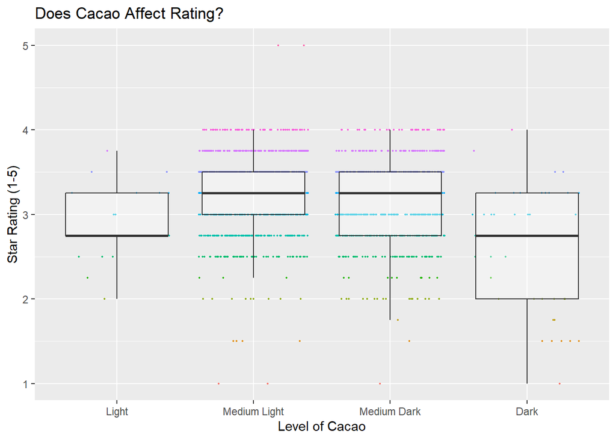

```r
   ggplot(data = choc2, aes(x= cocaoPercent, y = Rating, color = Rating)) +
    geom_jitter(size= 0.43, height = 0, width = NULL, aes(color = as.factor(Rating)))  +
     geom_boxplot(outlier.color = FALSE, alpha = .37) +
      theme(legend.position = "none") +
       labs(y = 'Star Rating (1-5)', x = "Level of Cacao", title ="Does Cacao Affect Rating?")
```

### Numerical Summary

```r
 favstats(Rating ~ cocaoPercent, data = choc2) %>%
  pander()
```

| cocaoPercent | min | Q1 | median | Q3 | max | mean | sd | n | missing |
| --- | --- | --- | --- | --- | --- | --- | --- | --- | --- |
| Light | 2 | 2.75 | 2.75 | 3.25 | 3.75 | 2.886 | 0.4277 | 22 | 0 |
| Medium Light | 1 | 3 | 3.25 | 3.5 | 5 | 3.25 | 0.4546 | 1008 | 0 |
| Medium Dark | 1 | 2.75 | 3.25 | 3.5 | 4 | 3.14 | 0.4621 | 719 | 0 |
| Dark | 1 | 2 | 2.75 | 3.25 | 4 | 2.622 | 0.7104 | 45 | 0 |

```r
kruskal.test(Rating ~ cocaoPercent, data = choc2) %>%
  pander()
```

Kruskal-Wallis rank sum test: `Rating` by `cocaoPercent`

| Test statistic | df | P value |
| --- | --- | --- |
| 65.98 | 3 | 3.091e-14 * * * |

## Conclusion

The results of the Kruskal-Wallis test allow us to conclude that we have sufficient evidence that at least one of the distributions is stochastically different from the others. We conclude this based on our p-value, $p = 3.091e^-14 < \alpha = 0.05$.

Based on our boxplots, we can conclude that the dark group and possibly the light group differ from the two medium groups. The chocolates with the highest average rating are the groups represented by the medium light and the medium dark groups. The averages both are just slightly above 3, which was previously defined as “satisfactory”, and is not quite in the range of “premium” chocolate. The averages of both light and dark chocolate are below the satisfactory range, and are approaching the range of being “disappointing”.

It may also be of value, to further this study, to change what percentages each group contains. Perhaps create only 3 groups instead of 4, that way we would not have as large of difference between sample sizes as we do now; the largest being 1008 - 22.